# Crashes Data Analysis

2023-07-18

The current model

```r
library(pROC)
gooddata3 <- read.csv("~/Desktop/gooddata3.csv")

model4 <- glm(Injury ~ DRIVER_SEX.y + DRIVER_SEX.x + DRIVER_SEX.x:DRIVER_SEX.y + young.y + young.x + licensed.x + licensed.y + instate_lic.x + instate_lic.y + instate_lic.x:instate_lic.y+ log(VW.x) + log(VW.y) + safe.x + safe.y + safe.x:safe.y,family=binomial(link='logit'),data=gooddata3)

summary(model4)
```

```
##
## Call:
## glm(formula = Injury ~ DRIVER_SEX.y + DRIVER_SEX.x + DRIVER_SEX.x:DRIVER_SEX.y +
##     young.y + young.x + licensed.x + licensed.y + instate_lic.x +
##     instate_lic.y + instate_lic.x:instate_lic.y + log(VW.x) +
##     log(VW.y) + safe.x + safe.y + safe.x:safe.y, family = binomial(link = "logit"),
##     data = gooddata3)
##
## Coefficients:
##                             Estimate Std. Error z value Pr(>|z|)
## (Intercept)                  1.80742    0.18717   9.656  < 2e-16 ***
## DRIVER_SEX.yM               -0.09946    0.02425  -4.101 4.11e-05 ***
## DRIVER_SEX.xM               -0.11126    0.02433  -4.573 4.80e-06 ***
## young.y                      0.18481    0.01730  10.683  < 2e-16 ***
## young.x                      0.16158    0.01736   9.310  < 2e-16 ***
## licensed.x                  -0.57298    0.04403 -13.013  < 2e-16 ***
## licensed.y                  -0.68961    0.04263 -16.178  < 2e-16 ***
## instate_lic.x                0.40843    0.05064   8.065 7.30e-16 ***
## instate_lic.y                0.40896    0.05067   8.071 6.97e-16 ***
## log(VW.x)                   -0.17297    0.01493 -11.589  < 2e-16 ***
## log(VW.y)                   -0.16270    0.01362 -11.947  < 2e-16 ***
## safe.x                      -0.15499    0.01615  -9.597  < 2e-16 ***
## safe.y                      -0.11816    0.01600  -7.386 1.52e-13 ***
## DRIVER_SEX.yM:DRIVER_SEX.xM -0.20452    0.02909  -7.031 2.05e-12 ***
## instate_lic.x:instate_lic.y -0.23930    0.05446  -4.394 1.11e-05 ***
## safe.x:safe.y               -0.03286    0.02697  -1.219    0.223
## ---
## Signif. codes:  0 '***' 0.001 '**' 0.01 '*' 0.05 '.' 0.1 ' ' 1
##
## (Dispersion parameter for binomial family taken to be 1)
##
##     Null deviance: 187862  on 262663  degrees of freedom
## Residual deviance: 185320  on 262648  degrees of freedom
##   (6927 observations deleted due to missingness)
## AIC: 185352
##
## Number of Fisher Scoring iterations: 5
```

```r
gooddata3$Injury.Pred <- predict(model4,newdata=gooddata3,type='response')

roc.test <- roc(gooddata3$Injury, gooddata3$Injury.Pred )
```

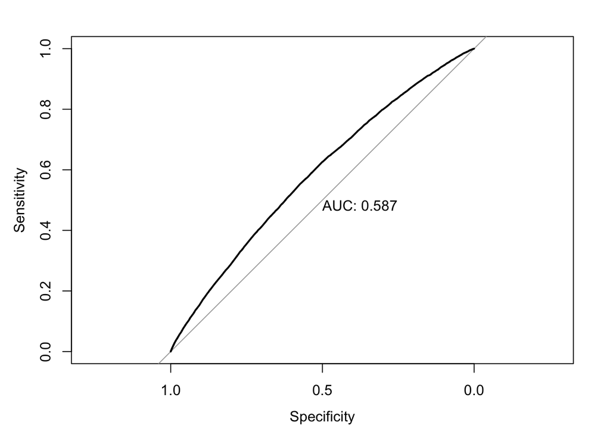

```r
plot(roc.test, print.auc = TRUE)
```

Background:

From the original three datasets, the following characteristics were selected for:

Complete data for all variables Only look at collisions involving two vehicles (vehicle 1 is denoted as .x, and vehicle 2 is denoted as .y) Only consider vehicles where the only occupant is the driver (that way we avoid the confounding effect that vehicles with multiple passengers are more likely to have injuries) Look at collisions involving vehicles belonging to a major class (e.g. no horse-drawn carriages) Ignore motorcycles/bicycles since they are so prone to injury/death that they overwhelm the rest of the findings

The Variables:

Driver Sex

```r
model_sex <- glm(Injury ~ DRIVER_SEX.y + DRIVER_SEX.x + DRIVER_SEX.x:DRIVER_SEX.y,family=binomial(link='logit'),data=gooddata3)

summary(model_sex)
```

```
##
## Call:
## glm(formula = Injury ~ DRIVER_SEX.y + DRIVER_SEX.x + DRIVER_SEX.x:DRIVER_SEX.y,
##     family = binomial(link = "logit"), data = gooddata3)
##
## Coefficients:
##                             Estimate Std. Error z value Pr(>|z|)
## (Intercept)                 -1.70769    0.01997 -85.511  < 2e-16 ***
## DRIVER_SEX.yM               -0.11658    0.02390  -4.878 1.07e-06 ***
## DRIVER_SEX.xM               -0.13607    0.02398  -5.674 1.40e-08 ***
## DRIVER_SEX.yM:DRIVER_SEX.xM -0.18932    0.02858  -6.623 3.52e-11 ***
## ---
## Signif. codes:  0 '***' 0.001 '**' 0.01 '*' 0.05 '.' 0.1 ' ' 1
##
## (Dispersion parameter for binomial family taken to be 1)
##
##     Null deviance: 197676  on 269590  degrees of freedom
## Residual deviance: 196837  on 269587  degrees of freedom
## AIC: 196845
##
## Number of Fisher Scoring iterations: 4
```

```r
gooddata3$Injury.Pred <- predict(model_sex,newdata=gooddata3,type='response')

roc.test <- roc(gooddata3$Injury, gooddata3$Injury.Pred )
```

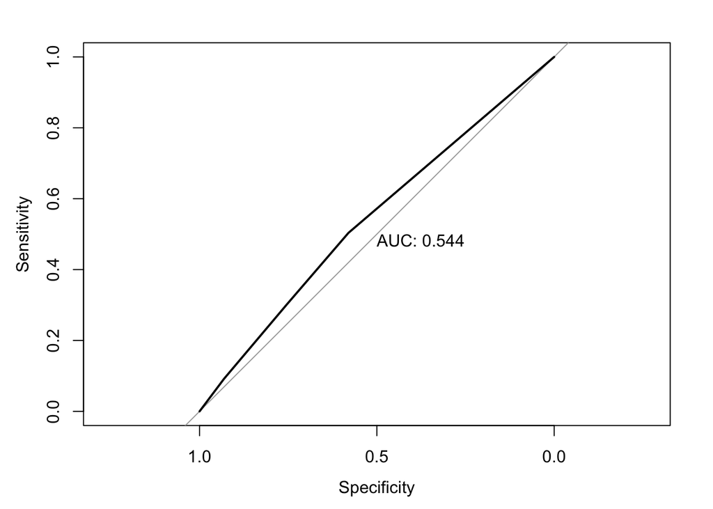

```r
plot(roc.test, print.auc = TRUE)
```

Sex is predictive at a high degree of confidence. Males have a lower risk of injury than females, and the effect is the same for both drivers in the crash. It should be mentioned that this does not imply that women are worse or more dangerous drivers, just that they are more likely to suffer injury in the event of a collision. (Or, rather, that an injury is more likely to occur in a collision involving a woman driver or two women drivers).

Driver Age

```r
model_age <- glm(Injury ~ PERSON_AGE.y + PERSON_AGE.x + PERSON_AGE.y:PERSON_AGE.x,family=binomial(link='logit'),data=gooddata3)

summary(model_age)
```

```
##
## Call:
## glm(formula = Injury ~ PERSON_AGE.y + PERSON_AGE.x + PERSON_AGE.y:PERSON_AGE.x,
##     family = binomial(link = "logit"), data = gooddata3)
##
## Coefficients:
##                             Estimate Std. Error  z value Pr(>|z|)
## (Intercept)               -1.886e+00  1.509e-02 -124.958  < 2e-16 ***
## PERSON_AGE.y              -1.801e-03  2.318e-04   -7.771 7.78e-15 ***
## PERSON_AGE.x              -7.623e-04  2.574e-04   -2.962  0.00306 **
## PERSON_AGE.y:PERSON_AGE.x  3.792e-07  5.211e-08    7.275 3.45e-13 ***
## ---
## Signif. codes:  0 '***' 0.001 '**' 0.01 '*' 0.05 '.' 0.1 ' ' 1
##
## (Dispersion parameter for binomial family taken to be 1)
##
##     Null deviance: 197676  on 269590  degrees of freedom
## Residual deviance: 197592  on 269587  degrees of freedom
## AIC: 197600
##
## Number of Fisher Scoring iterations: 5
```

```r
gooddata3$Injury.Pred <- predict(model_age,newdata=gooddata3,type='response')

roc.test <- roc(gooddata3$Injury, gooddata3$Injury.Pred )
```

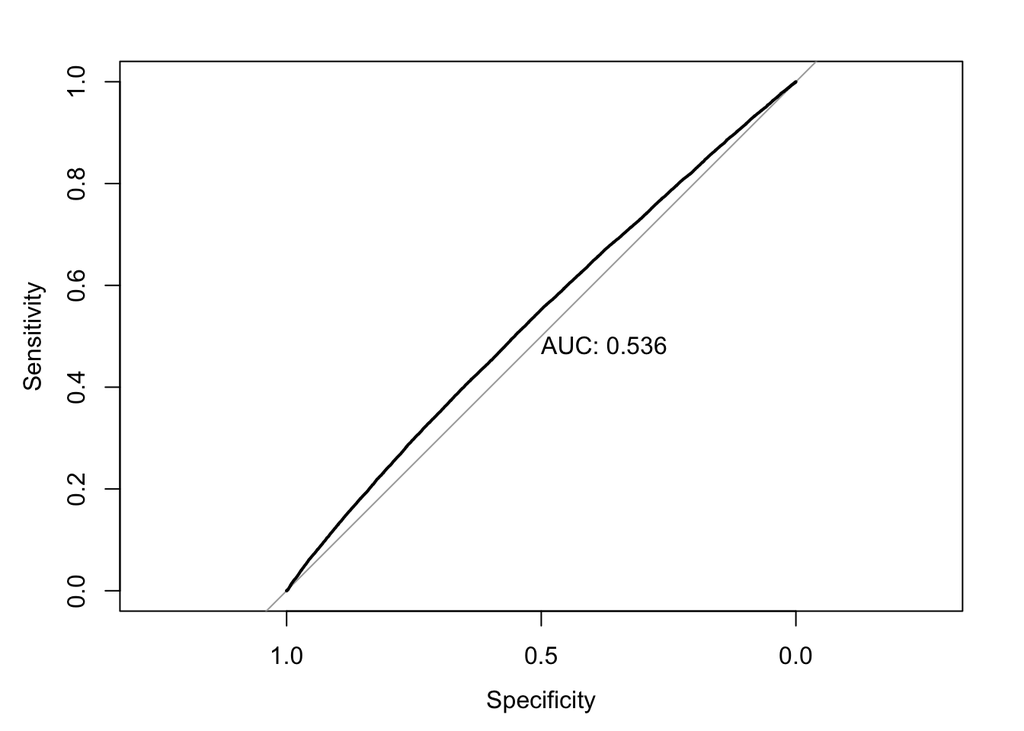

```r
plot(roc.test, print.auc = TRUE)
```

Age is significant, but it isn’t clear what the effects are. My suspicion is that the effect of age is mostly limited to very young (rash and inexperienced) drivers and very old (possibly feeble) drivers. I’m going to try to create categorical variables to see if that improves the fit.

Driver Age2

```r
gooddata3$young.y <- 0
gooddata3$young.x <- 0
gooddata3$young.y[(gooddata3$PERSON_AGE.y <= 25)] <- 1
gooddata3$young.x[(gooddata3$PERSON_AGE.x <= 25)] <- 1

gooddata3$old.y <- 0
gooddata3$old.x <- 0
gooddata3$old.y[(gooddata3$PERSON_AGE.y >= 75)] <- 1
gooddata3$old.x[(gooddata3$PERSON_AGE.x >= 75)] <- 1


model_age2 <- glm(Injury ~ young.y + young.x + young.y:young.x + old.y + old.x + old.y:old.x ,family=binomial(link='logit'),data=gooddata3)

summary(model_age2)
```

```
##
## Call:
## glm(formula = Injury ~ young.y + young.x + young.y:young.x +
##     old.y + old.x + old.y:old.x, family = binomial(link = "logit"),
##     data = gooddata3)
##
## Coefficients:
##                  Estimate Std. Error  z value Pr(>|z|)
## (Intercept)     -2.057620   0.007105 -289.610   <2e-16 ***
## young.y          0.259619   0.018082   14.358   <2e-16 ***
## young.x          0.226493   0.018214   12.435   <2e-16 ***
## old.y           -0.001052   0.043725   -0.024   0.9808
## old.x           -0.110616   0.045068   -2.454   0.0141 *
## young.y:young.x -0.046797   0.046181   -1.013   0.3109
## old.y:old.x     -0.271558   0.203319   -1.336   0.1817
## ---
## Signif. codes:  0 '***' 0.001 '**' 0.01 '*' 0.05 '.' 0.1 ' ' 1
##
## (Dispersion parameter for binomial family taken to be 1)
##
##     Null deviance: 197676  on 269590  degrees of freedom
## Residual deviance: 197268  on 269584  degrees of freedom
## AIC: 197282
##
## Number of Fisher Scoring iterations: 4
```

```r
gooddata3$Injury.Pred <- predict(model_age2,newdata=gooddata3,type='response')

roc.test <- roc(gooddata3$Injury, gooddata3$Injury.Pred )
```

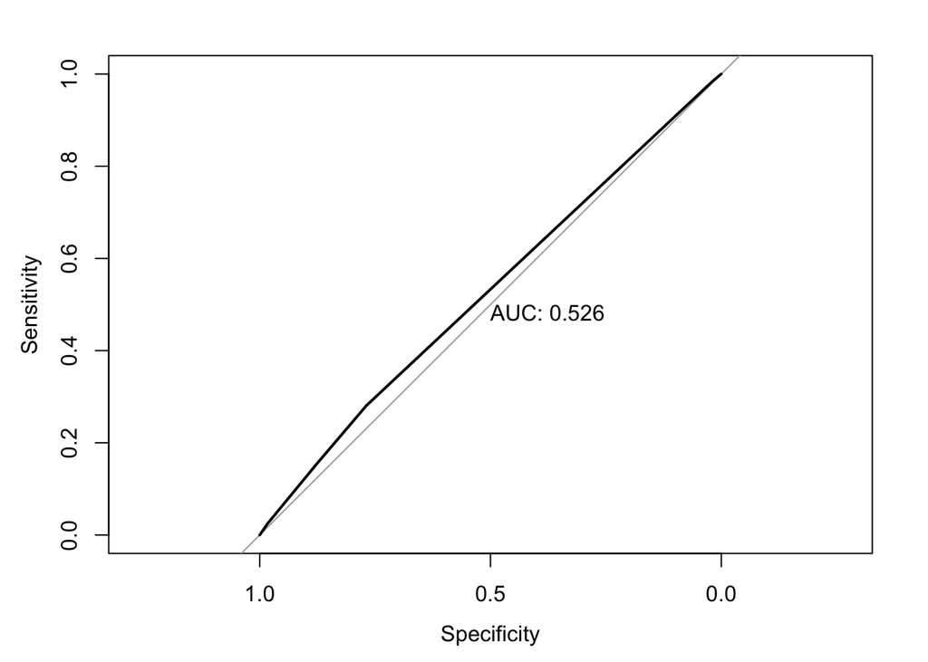

```r
plot(roc.test, print.auc = TRUE)
```

```r
model_age3 <- glm(Injury ~ young.y + young.x,family=binomial(link='logit'),data=gooddata3)

summary(model_age3)
```

```
##
## Call:
## glm(formula = Injury ~ young.y + young.x, family = binomial(link = "logit"),
##     data = gooddata3)
##
## Coefficients:
##              Estimate Std. Error z value Pr(>|z|)
## (Intercept) -2.059536   0.006885 -299.13   <2e-16 ***
## young.y      0.252905   0.016619   15.22   <2e-16 ***
## young.x      0.222056   0.016721   13.28   <2e-16 ***
## ---
## Signif. codes:  0 '***' 0.001 '**' 0.01 '*' 0.05 '.' 0.1 ' ' 1
##
## (Dispersion parameter for binomial family taken to be 1)
##
##     Null deviance: 197676  on 269590  degrees of freedom
## Residual deviance: 197280  on 269588  degrees of freedom
## AIC: 197286
##
## Number of Fisher Scoring iterations: 4
```

```r
gooddata3$Injury.Pred <- predict(model_age3,newdata=gooddata3,type='response')

roc.test <- roc(gooddata3$Injury, gooddata3$Injury.Pred )
```

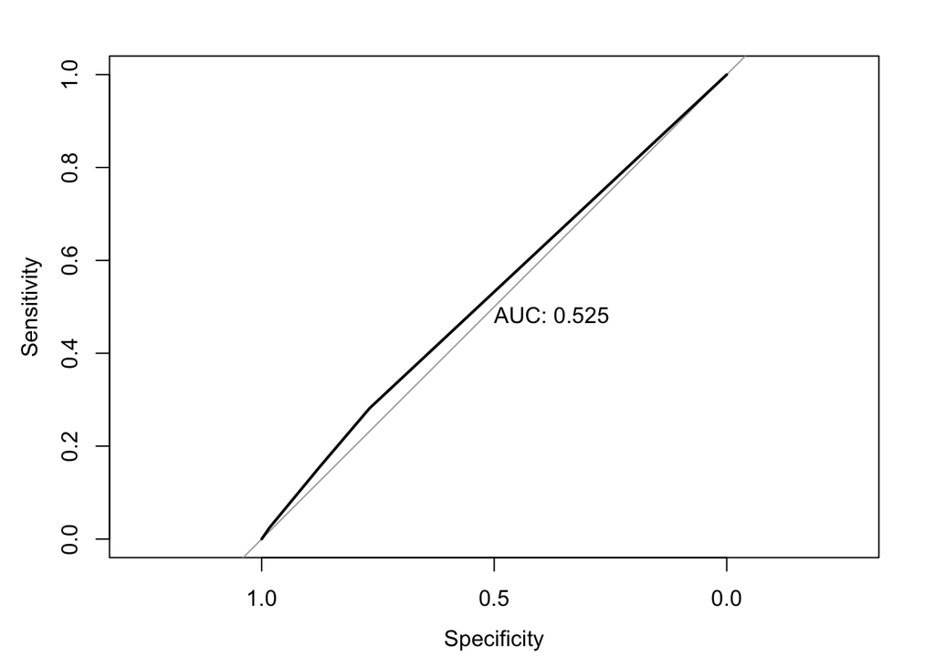

```r
plot(roc.test, print.auc = TRUE)
```

The AUC is higher including the continuous variable rather than the categorical variable. I will keep this in mind later when combining variables.

Licensing

```r
gooddata3$licensed.x <- 0
gooddata3$licensed.y <- 0
gooddata3$licensed.y[(gooddata3$DRIVER_LICENSE_STATUS.y == 'Licensed')] <- 1
gooddata3$licensed.x[(gooddata3$DRIVER_LICENSE_STATUS.x == 'Licensed')] <- 1


model_lic <- glm(Injury ~ licensed.x + licensed.y + licensed.x:licensed.y,family=binomial(link='logit'),data=gooddata3)

summary(model_lic)
```

```
##
## Call:
## glm(formula = Injury ~ licensed.x + licensed.y + licensed.x:licensed.y,
##     family = binomial(link = "logit"), data = gooddata3)
##
## Coefficients:
##                       Estimate Std. Error z value Pr(>|z|)
## (Intercept)            -0.8729     0.2073  -4.212 2.54e-05 ***
## licensed.x             -0.3229     0.2109  -1.531   0.1258
## licensed.y             -0.4462     0.2111  -2.113   0.0346 *
## licensed.x:licensed.y  -0.3802     0.2148  -1.770   0.0766 .
## ---
## Signif. codes:  0 '***' 0.001 '**' 0.01 '*' 0.05 '.' 0.1 ' ' 1
##
## (Dispersion parameter for binomial family taken to be 1)
##
##     Null deviance: 197676  on 269590  degrees of freedom
## Residual deviance: 197022  on 269587  degrees of freedom
## AIC: 197030
##
## Number of Fisher Scoring iterations: 4
```

```r
gooddata3$Injury.Pred <- predict(model_lic,newdata=gooddata3,type='response')

roc.test <- roc(gooddata3$Injury, gooddata3$Injury.Pred )
```

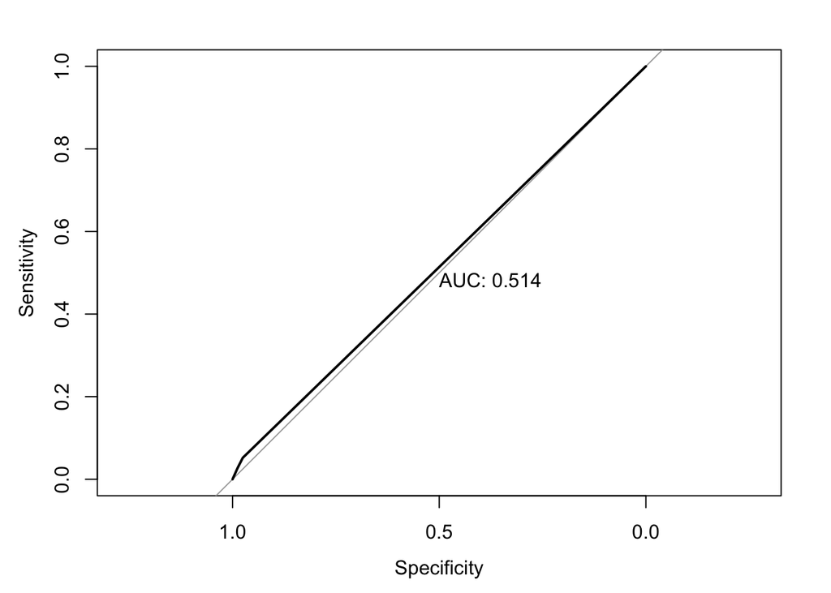

```r
plot(roc.test, print.auc = TRUE)
```

Interesting. Licensing is barely significant when included as a variable by itself, but (spoiler) it becomes very relevant when included in the multi-variable model. This could be because there are so few collisions that involved unlicensed or permitted drivers. I’ll come back to this later.

In-state Licensing

```r
gooddata3$instate_lic.x <- 0
gooddata3$instate_lic.y <- 0
gooddata3$instate_lic.y[(gooddata3$DRIVER_LICENSE_JURISDICTION.y == 'NY')] <- 1
gooddata3$instate_lic.x[(gooddata3$DRIVER_LICENSE_JURISDICTION.x == 'NY')] <- 1

model_instate <- glm(Injury ~ instate_lic.x + instate_lic.y + instate_lic.x:instate_lic.y,family=binomial(link='logit'),data=gooddata3)

summary(model_instate)
```

```
##
## Call:
## glm(formula = Injury ~ instate_lic.x + instate_lic.y + instate_lic.x:instate_lic.y,
##     family = binomial(link = "logit"), data = gooddata3)
##
## Coefficients:
##                             Estimate Std. Error z value Pr(>|z|)
## (Intercept)                 -2.57598    0.04489 -57.384  < 2e-16 ***
## instate_lic.x                0.45804    0.04842   9.459  < 2e-16 ***
## instate_lic.y                0.46254    0.04843   9.551  < 2e-16 ***
## instate_lic.x:instate_lic.y -0.28496    0.05216  -5.463 4.68e-08 ***
## ---
## Signif. codes:  0 '***' 0.001 '**' 0.01 '*' 0.05 '.' 0.1 ' ' 1
##
## (Dispersion parameter for binomial family taken to be 1)
##
##     Null deviance: 197676  on 269590  degrees of freedom
## Residual deviance: 197322  on 269587  degrees of freedom
## AIC: 197330
##
## Number of Fisher Scoring iterations: 5
```

```r
gooddata3$Injury.Pred <- predict(model_instate,newdata=gooddata3,type='response')

roc.test <- roc(gooddata3$Injury, gooddata3$Injury.Pred )
```

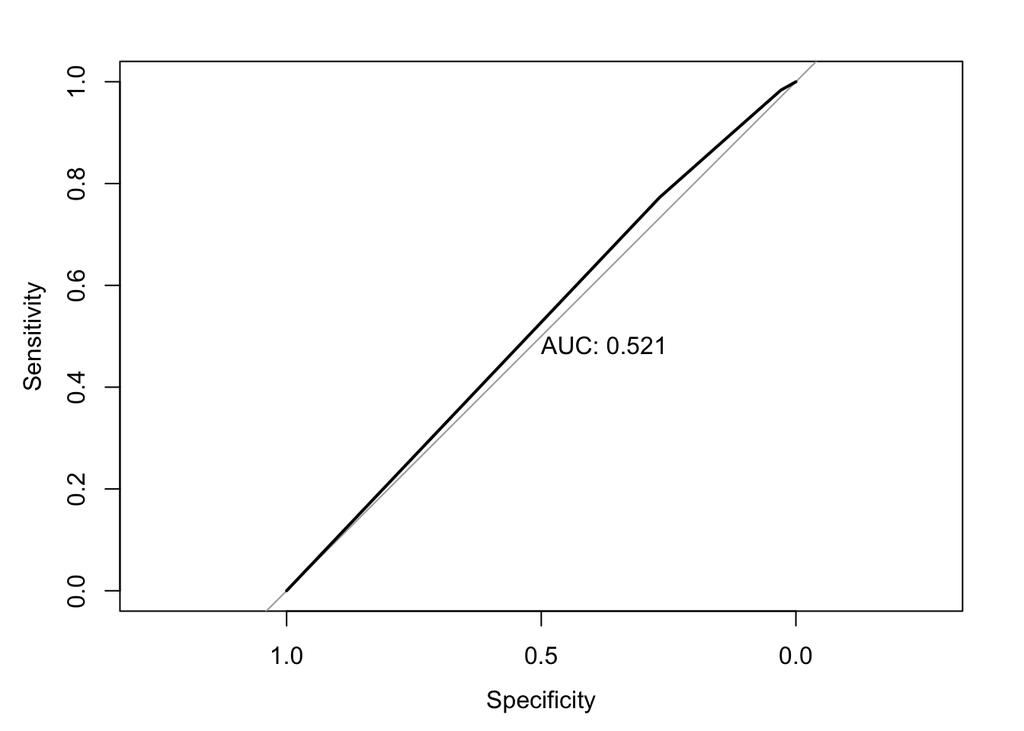

```r
plot(roc.test, print.auc = TRUE)
```

Very odd finding that in-state drivers are actually slightly *more* likely to be injured in an accident than out-of-state drivers. One possible explanation is that people in NYC don’t actually drive that much. The interaction term is also strange, indicating that the risk of injury is lowered when there is a collision between two in-state drivers. No idea what’s going on here - let’s keep this in mind for the variable consolidation step.

Car Safety

```r
model_car_make1 <- glm(Injury ~ VM.x,family=binomial(link='logit'),data=gooddata3)
model_car_make2 <- glm(Injury ~ VM.y,family=binomial(link='logit'),data=gooddata3)

summary(model_car_make1)
```

```
##
## Call:
## glm(formula = Injury ~ VM.x, family = binomial(link = "logit"),
##     data = gooddata3)
##
## Coefficients:
##               Estimate Std. Error z value Pr(>|z|)
## (Intercept) -1.939e+00  4.192e-02 -46.260  < 2e-16 ***
## VM.xallo    -1.210e-01  4.575e-02  -2.645 0.008161 **
## VM.xaudi    -2.044e-01  7.306e-02  -2.797 0.005153 **
## VM.xbmw      9.536e-02  5.298e-02   1.800 0.071886 .
## VM.xchev    -7.934e-02  4.971e-02  -1.596 0.110476
## VM.xchry    -4.553e-02  6.831e-02  -0.666 0.505100
## VM.xdodg    -4.014e-03  5.549e-02  -0.072 0.942323
## VM.xford    -1.782e-01  4.666e-02  -3.818 0.000134 ***
## VM.xgmc     -2.832e-01  7.043e-02  -4.021 5.79e-05 ***
## VM.xhond     8.724e-02  4.504e-02   1.937 0.052746 .
## VM.xhyun     1.052e-01  5.144e-02   2.044 0.040947 *
## VM.xinfi     1.224e-01  5.890e-02   2.077 0.037767 *
## VM.xjeep     3.784e-05  5.301e-02   0.001 0.999430
## VM.xkia      6.214e-02  6.877e-02   0.904 0.366182
## VM.xlexs    -1.095e-01  5.735e-02  -1.910 0.056148 .
## VM.xlinc    -1.446e-01  7.056e-02  -2.050 0.040369 *
## VM.xlndr    -1.815e-01  1.068e-01  -1.699 0.089262 .
## VM.xmazd     6.409e-02  7.037e-02   0.911 0.362416
## VM.xmerz    -8.499e-02  5.346e-02  -1.590 0.111922
## VM.xmits     3.143e-02  7.912e-02   0.397 0.691188
## VM.xniss     1.032e-01  4.544e-02   2.271 0.023145 *
## VM.xsuba    -1.247e-01  6.668e-02  -1.870 0.061430 .
## VM.xtoyt    -1.999e-01  4.422e-02  -4.520 6.18e-06 ***
## VM.xvolk    -2.820e-02  6.443e-02  -0.438 0.661580
## VM.xvolv    -2.537e-01  8.984e-02  -2.824 0.004744 **
## ---
## Signif. codes:  0 '***' 0.001 '**' 0.01 '*' 0.05 '.' 0.1 ' ' 1
##
## (Dispersion parameter for binomial family taken to be 1)
##
##     Null deviance: 197676  on 269590  degrees of freedom
## Residual deviance: 197242  on 269566  degrees of freedom
## AIC: 197292
##
## Number of Fisher Scoring iterations: 4
```

```r
summary(model_car_make2)
```

```
##
## Call:
## glm(formula = Injury ~ VM.y, family = binomial(link = "logit"),
##     data = gooddata3)
##
## Coefficients:
##               Estimate Std. Error z value Pr(>|z|)
## (Intercept) -1.8833504  0.0405109 -46.490  < 2e-16 ***
## VM.yallo    -0.2117804  0.0445828  -4.750 2.03e-06 ***
## VM.yaudi    -0.1754176  0.0706894  -2.482 0.013082 *
## VM.ybmw      0.0255492  0.0518758   0.493 0.622361
## VM.ychev    -0.1995757  0.0488755  -4.083 4.44e-05 ***
## VM.ychry    -0.0661337  0.0671129  -0.985 0.324422
## VM.ydodg     0.0206054  0.0534886   0.385 0.700067
## VM.yford    -0.2397469  0.0454026  -5.280 1.29e-07 ***
## VM.ygmc     -0.2308213  0.0676371  -3.413 0.000643 ***
## VM.yhond     0.0221945  0.0437870   0.507 0.612243
## VM.yhyun    -0.0101918  0.0505397  -0.202 0.840184
## VM.yinfi     0.0006192  0.0587357   0.011 0.991589
## VM.yjeep     0.0019193  0.0516635   0.037 0.970365
## VM.ykia      0.0003447  0.0674578   0.005 0.995923
## VM.ylexs    -0.2086486  0.0563543  -3.702 0.000214 ***
## VM.ylinc    -0.3100474  0.0715132  -4.336 1.45e-05 ***
## VM.ylndr    -0.1361930  0.1020866  -1.334 0.182174
## VM.ymazd    -0.1226930  0.0716373  -1.713 0.086768 .
## VM.ymerz    -0.1544707  0.0524541  -2.945 0.003231 **
## VM.ymits     0.0435625  0.0769242   0.566 0.571187
## VM.yniss     0.0393779  0.0441849   0.891 0.372819
## VM.ysuba    -0.2615062  0.0670116  -3.902 9.52e-05 ***
## VM.ytoyt    -0.2114949  0.0428256  -4.939 7.87e-07 ***
## VM.yvolk     0.0279372  0.0618304   0.452 0.651387
## VM.yvolv    -0.2907517  0.0894670  -3.250 0.001155 **
## ---
## Signif. codes:  0 '***' 0.001 '**' 0.01 '*' 0.05 '.' 0.1 ' ' 1
##
## (Dispersion parameter for binomial family taken to be 1)
##
##     Null deviance: 197676  on 269590  degrees of freedom
## Residual deviance: 197282  on 269566  degrees of freedom
## AIC: 197332
##
## Number of Fisher Scoring iterations: 4
```

```r
#gooddata3$Injury.Pred <- predict(model_car_make,newdata=gooddata3,type='response')

#roc.test <- roc(gooddata3$Injury, gooddata3$Injury.Pred )

#plot(roc.test, print.auc = TRUE)
```

As you can tell from the summary data, some car makes appear to be less frequently associated with injuries than others. In the VM.x dataset, the makes that are statistically-significantly associated with injury reduction are toyota, volvo, audi, ford, gmc, lincoln, lexus (close enough), and subaru. I included Land Rover initially for some weird reason initially but I think I’m going to take it out on the second run. These cars are also significantly safer in the VM.y field, indicating that the relationship is unlikely due to overfitting. It is also worth noting that makes that are made by the same company (e.g. Toyota/Lexus, Honda/Acura, Nissan/Infiniti, Dodge/Chrysler, etc.) tend to have coefficients pointing in the same direction.

```r
safe_cars_final <- c("toyt", "volv", "ford", "audi", "gmc", "linc", "lexs", "suba")

gooddata3$safe.x <- 0
gooddata3$safe.y <- 0
gooddata3$safe.x[(gooddata3$VM.x %in% safe_cars_final)] <- 1
gooddata3$safe.y[(gooddata3$VM.y %in% safe_cars_final)] <- 1


model_car_safe <- glm(Injury ~ safe.x + safe.y + safe.x:safe.y,family=binomial(link='logit'),data=gooddata3)

summary(model_car_safe)
```

```
##
## Call:
## glm(formula = Injury ~ safe.x + safe.y + safe.x:safe.y, family = binomial(link = "logit"),
##     data = gooddata3)
##
## Coefficients:
##                Estimate Std. Error  z value Pr(>|z|)
## (Intercept)   -1.866481   0.008943 -208.698   <2e-16 ***
## safe.x        -0.185863   0.015493  -11.997   <2e-16 ***
## safe.y        -0.156623   0.015376  -10.186   <2e-16 ***
## safe.x:safe.y -0.049799   0.026541   -1.876   0.0606 .
## ---
## Signif. codes:  0 '***' 0.001 '**' 0.01 '*' 0.05 '.' 0.1 ' ' 1
##
## (Dispersion parameter for binomial family taken to be 1)
##
##     Null deviance: 197676  on 269590  degrees of freedom
## Residual deviance: 197208  on 269587  degrees of freedom
## AIC: 197216
##
## Number of Fisher Scoring iterations: 4
```

```r
gooddata3$Injury.Pred <- predict(model_car_safe,newdata=gooddata3,type='response')

roc.test <- roc(gooddata3$Injury, gooddata3$Injury.Pred )
```

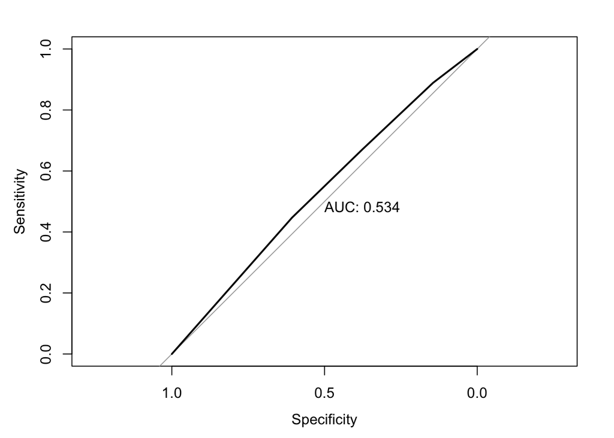

```r
plot(roc.test, print.auc = TRUE)
```